# Exploración de datos sobre Migraña

Ivan Cruz

```r
library(dplyr)
library(tidyverse)
```

## 0.1 Introducción:

La migraña o dolor de cabeza es uno de los síntomas más frecuentes que ven los neurólogos. Es una enfermadad muy común en la población general. Un estudio reveló que más del 90% de la población sufre de dolores de cabeza **[1]**.

Los trastornos de cefalea primaria son más prevalentes en las personas a nivel mundial, mientras que la tasa activa estimada de cefaleas por tensión y migraña es aproximadamente del 40% y del 10%, respectivamente. Por otro lado, la cefalea en racimos, también conocida como cefalea autonómica trigeminal, es esporádica en comparación con las cefaleas por tensión y las migrañas, donde su ocurrencia en la población es cercana al 0.1% **[1]**.

## 0.2 Contexto del problema

Para una comprension más detallada ver el `video aquí`: https://www.youtube.com/watch?v=COx-2Zk6cFQ.

[figure not shown]

## 0.3 Dataset

Fuente del dataset: https://www.kaggle.com/datasets/ukveteran/treatment-of-migraine-headaches/data.

```r
# Carga de datos del archivo csv
 #file.choose()
bd_mcabeza=read.csv("KosteckiDillon.csv")
bd_mcabeza
```

| X | id | time | dos | hatype | age | airq | medication | headache | sex |
| --- | --- | --- | --- | --- | --- | --- | --- | --- | --- |
| 1 | 1 | -11 | 753 | Aura | 30 | 9.0 | continuing | yes | female |
| 2 | 1 | -10 | 754 | Aura | 30 | 7.0 | continuing | yes | female |
| 3 | 1 | -9 | 755 | Aura | 30 | 10.0 | continuing | yes | female |
| 4 | 1 | -8 | 756 | Aura | 30 | 13.0 | continuing | yes | female |
| 5 | 1 | -7 | 757 | Aura | 30 | 18.0 | continuing | yes | female |
| 6 | 1 | -6 | 758 | Aura | 30 | 19.0 | continuing | yes | female |
| 7 | 1 | -5 | 759 | Aura | 30 | 17.0 | continuing | yes | female |
| 8 | 1 | 22 | 786 | Aura | 30 | 21.0 | continuing | yes | female |
| 9 | 1 | 23 | 787 | Aura | 30 | 21.0 | continuing | yes | female |
| 10 | 1 | 24 | 788 | Aura | 30 | 18.0 | continuing | yes | female |

[output cut: 4142 more lines]

Caracteristicas del dataset

```r
# Columnas de la BD - La función colnames() permite ver el nombre de las columnas
colnames(bd_mcabeza)
```

```
##  [1] "X"          "id"         "time"       "dos"        "hatype"
##  [6] "age"        "airq"       "medication" "headache"   "sex"
```

```r
# Tamaño asociado: función dim()
dim(bd_mcabeza)
```

```
## [1] 4152   10
```

El dataset contiene registros de estudio de 133 pacientes.

**NOTA:** la columna `x` se eliminará dado que es valor de conteo.

```r
bd_mcabeza <- bd_mcabeza %>% select(-X)
colnames(bd_mcabeza)
```

```
## [1] "id"         "time"       "dos"        "hatype"     "age"
## [6] "airq"       "medication" "headache"   "sex"
```

## 0.4 Exploración de los datos

Verificamos la población de la muestra entre hombre y mujeres.

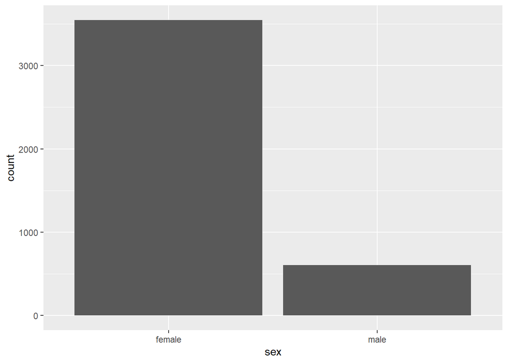

```r
 ggplot(bd_mcabeza, aes(x = sex)) + geom_bar()
```

Los estudios muestran que las mujeres experimentan ataques de migraña con mayor frecuencia que los hombres. Si graficamos los datos podemos verificar que dicha información tambien esta presente en el dataset usado **[2][3]**.

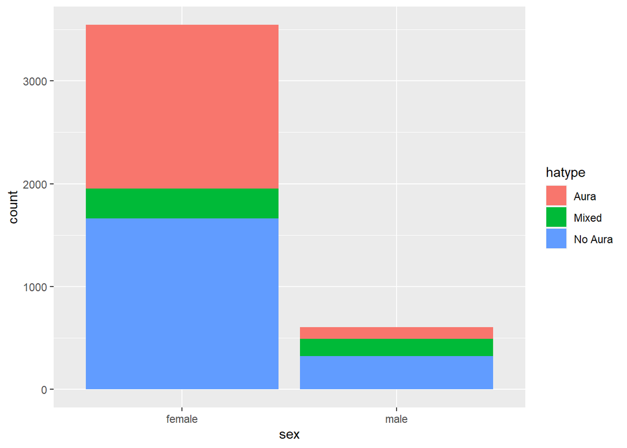

```r
bd_mcabeza %>%
  ggplot(aes(x = sex,fill = hatype)) +
  geom_bar()
```